# Ranges of parameters used

Mo Yin

5/21/2021

This document includes how the ranges for the various models were decided and the respective references used.

## $\color{blue}{\text{Ward characteristics}}$

### n.bed

Taken arbitrarily at 5-50

### max.los

How does max.los relate to final distribution of los, given that:

- From the los_abx_matrix*.R function

```r
all_los = ceiling(rexp(n.patient, 1/max.los))
all_los[all_los > (5 * max.los)] = ceiling(max.los)
```

- Also, in the following step, prescription of antibiotic during admission, may prolong los (in the varydur function)?

If we take the following values and plug into los_abx_table_varydur.R:

```r
n = 100

para.df = data.frame(max.los = runif(n, min = 3, max = 20),
                     n.bed = runif(n, min = 5, max = 50),
                     n.day = 400,
                     p.infect = runif(n, min = 0.1, max = 1),
                     p.r.day1 = runif(n, min = 0.1, max = 1),
                     p.r.after = runif(n, min = 0.1, max = 1),
                     cum.r.1 = runif(n, min = 30, max = 300),
                     meanDur = runif(n, min = 3, max = 21),
                     timestep = 1)
```

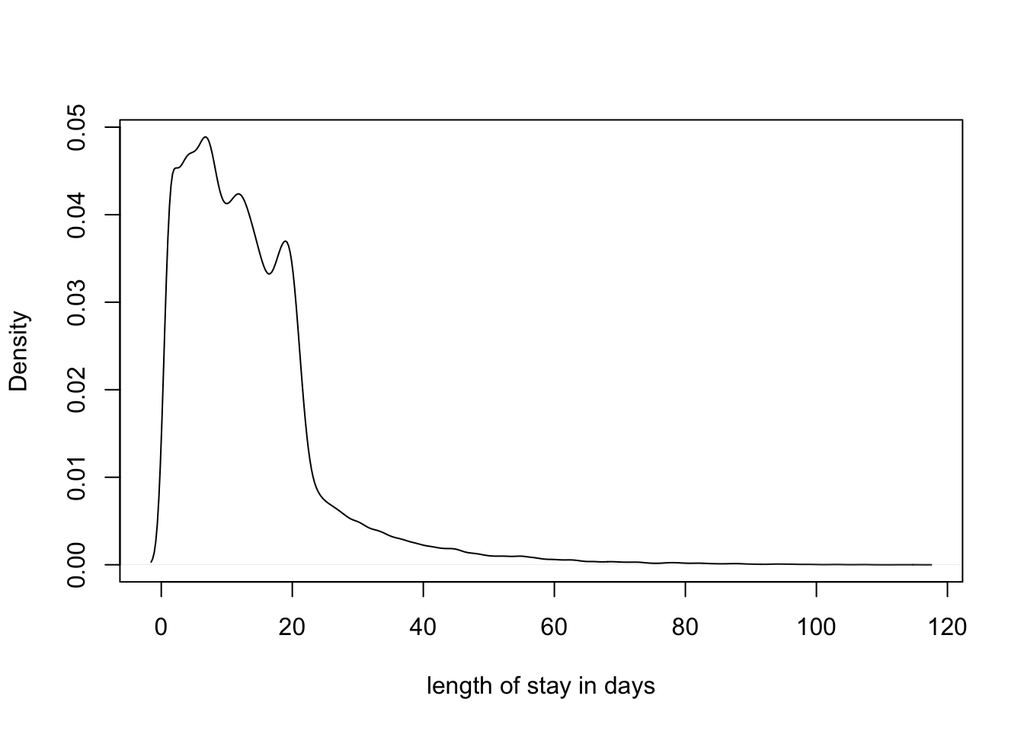

## $\color{blue}{\text{Antibiotic prescription}}$

### p.infect, p.r.day1, p.r.after

Taken arbitrarily at 0.1 to 1

### cum.r.1

How does cum.r.1 relate to the proportion of patients receiving antibiotics in the ward on any given day?

If we take the following values and plug into los_abx_table_varydur.R (same as above):

```r
n = 100

para.df = data.frame(max.los = runif(n, min = 3, max = 20),
                     n.bed = runif(n, min = 5, max = 50),
                     n.day = 400,
                     p.infect = runif(n, min = 0.1, max = 1),
                     p.r.day1 = runif(n, min = 0.1, max = 1),
                     p.r.after = runif(n, min = 0.1, max = 1),
                     cum.r.1 = runif(n, min = 30, max = 300),
                     meanDur = runif(n, min = 3, max = 21),
                     timestep = 1)
```

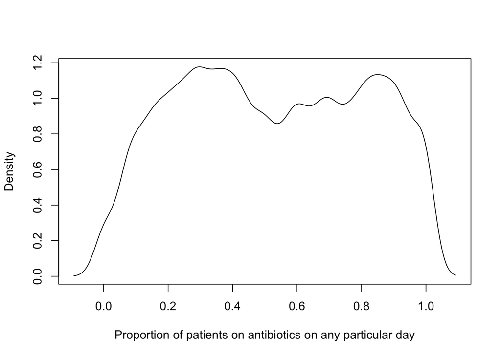

## $\color{blue}{\text{Transmission}}$

### pi_ssr

Community setting:

- Tangden 2010: 24/ 100 acquired ESBL-producing Escherichia coli after the trip. The median length of stay abroad was 2 weeks (range, 1 to 26 weeks).

Hospital setting:

- Hilty 2012: A total of 88 hospital patients were exposed for 715 days to the 40 index in patients with ESBL-Ec for a mean (± SD) of 8.1 days (± 5.8). The mean (± SD) follow-up time of the hospital contacts was 27.6 days (± 40.0). The overall transmission rate for ESBL-Ec was 4.5% (4 of 88 exposed contacts), corresponding to an incidence of transmission of 5.6 cases per 1000 exposure days. ESBL-Kp: 8.3%
- Fankhauser 2009: Transmission rate of 2.8% and 4.2 cases per 1000 exposure days
- Uemura 2017: 1 month 41 beds, 20 new cases = ~ 30 days for cumulative risk to become 0.50
- Maamar 2016: 2 months, 63 patients baseline ESBL carriage 20.63% (13/63) at admission. Among the 50 non-carriers, 35 were resampled during their hospitalization and the acquisition rate was 42.85% (15/35).
- Tran 2019: Prevalence of CRE colonisation increased on average 4.2%/day and mean CRE colonisation rates increased from 13% on the day of admission to 89% at day 15 of hospital stay. At the NICU, CRE colonisation increased from 32% at admission to 87% at discharge

Hence upper limit of pi_ssr = 80% cumulative risk in 2 weeks (Tran); Lower limit of pi_ssr = 0

In all three models, transmissions are modeled as independent events depending on the number of other R carriers in the ward.

```r
n = 100

# range of transmission parameter and max number of R carriers in the ward given the ward capacity
pi_ssr = runif(n, min = 0, max = 0.3)
```

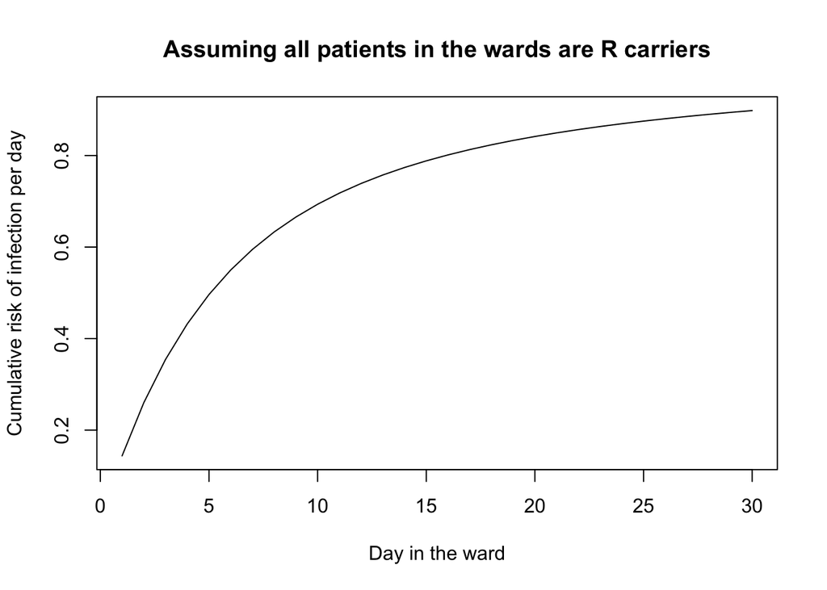

### r_thres and r_trans (population growth model)

Taken arbitrarily at 0.01 to 0.2

### bif (simple 3 state model)

Taken arbitrarily at 0 to 1

## $\color{blue}{\text{Baseline carriage status}}$

### prop_R

How many Rs (and sR, Sr, sr, s, S) are there on admission?

Codes from the various models to determine initial carriage status

```r
# simple 3 state model
prop_R = c("qunif", list(min=0, max=0.8))       #"prob_StartBact_R",probability of initial carriage of resistant organisms
prop_S = c("qunif", list(min=0, max=1))         #"prop_S", proportion of S in the population of S and ss

prop_start_S = prop_S * (1 - prop_R)

# cocarriage 5 state model
prop_R = c("qunif", list(min=0, max=0.8))          #probability of initial carriage of resistant organisms
prop_r = c("qunif", list(min=0, max=1))            #proportion of S in (S+s): prob_start_S <- prop_S_nonR*(1-prob_R)
prop_Sr = c("qunif", list(min=0, max=1))           #proportion of Sr in (r+R): prob_start_Sr <- prop_Sr_inR*prob_R
prop_S = c("qunif", list(min=0, max=1))            #proportion of sr in (r+r): prob_start_sr <- prop_sr_inR*prob_R

prob_start_sR = prop_R
#S, ss, Sr, sr come from (1-prop_R)
#Sr, sr come from prop_r*(1-prop_R)
prob_start_Sr = prop_Sr * prop_r * (1 - prop_R)
prob_start_sr = (1 - prop_Sr) * prop_r * (1 - prop_R)
#S, ss come from (1-prop_r)*(1-prop_R)
prob_start_S = prop_S * (1 - prop_r) * (1 - prop_R)
prob_start_ss = (1 - prop_S) * (1 - prop_r) * (1 - prop_R)

# population growth model
total_capacity = rnorm(number_of_patients, mean = K) #in log
total_capacity_matrix = matrix(rep(total_capacity, los.array[2,]), byrow = F, ncol = ncol(patient.matrix)) #in log

#existing population
#existing population mean is proportion (total_prop) of total capacity instead of a proportion of the
#distribution of the total capacity so that some starts at full capacity while others are not
#which is similar to model 2 where there is sr
total_existing_mean = log(total_prop * exp(total_capacity)) #in log
total_existing = rnorm(number_of_patients, mean = total_existing_mean) #total number of Enterobacteriaceae is a proportion of the capacity (log)
total_existing [which(total_existing >= total_capacity)] = total_capacity [which(total_existing >= total_capacity)] #those exceeding total capacity will be given their own full capacity

#amount of S and R carried
r_thres_log = log(r_thres * exp(total_existing)) # a proportion of the total gut capacity
r_thres_matrix = matrix(rep(r_thres_log, los.array[2,]), byrow = F, ncol = ncol(patient.matrix)) #in log

morethan_rthres = which(total_existing > r_thres_log)  #pick patients who have existing Enterobacteriaceae more than r_thres (log)
r.id = sample(morethan_rthres, size = floor(prop_R * number_of_patients))
if (length(r.id) > 0) {s.id = (1:number_of_patients) [-r.id]} else {s.id = (1:number_of_patients)}
```

Taking the same para.list as above, and taking prop_R 0 to 0.8, and other parameters as above.

Starting states for patients admitted into the wards (mean proportion of all the admitted patients per iteration):

| 1 | R | S | ss | sr | Sr |
| --- | --- | --- | --- | --- | --- |
| Simple 3 state | 0.41 | 0.32 | 0.27 |  |  |
| Co-carriage 5 state | 0.38 | 0.15 | 0.15 | 0.15 | 0.16 |
| Population growth | 0.38 |  |  |  |  |

### K (population growth model) (Mean total gut carrying capacity for Enterobacteriaceae (log scale))

Hence, if total carrying capacity of gut 25-28, and proportion of Enterobacteriaceae 0.001 to 0.01, then K = 18-24

### total_prop (population growth model)

Taken arbitrarily at 0.1 to 0.9

## $\color{blue}{\text{Decolonisation}}$

### mu (simple 3 state and cocarriage 5 state model)

- Haggai Bar-Yoseph 2016: colonization 100% at baseline, to 76.7% (95% CI=69.3%–82.8%) at 1 month, to 35.2% (95% CI=28.2%–42.9%) at 12 months = decolonized 17.2-30.7% 1 month, 57.1-71.8% 12 months
- Mo 2020: probability of decolonization in 1 year was 98.5%, mean carriage duration was 86 days

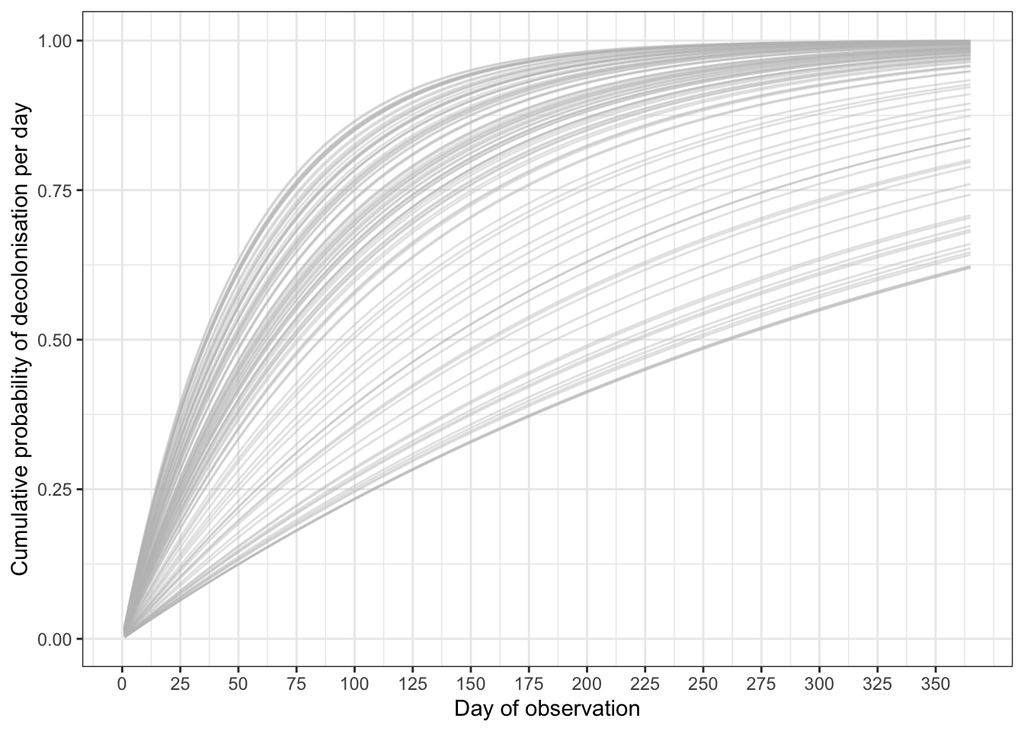

## Enterobacteriaceae growth

### repop.s (simple 3 state and cocarriage 5 state model)

- Palleja 2018: 12 healthy men over a 6-month period following a 4-day intervention with a cocktail of meropenem, gentamicin and vancomycin. The gut microbiota of the subjects recovered to near-baseline composition within 1.5 months, although 9 common species, which were present in all subjects before the treatment, remained undetectable in most of the subjects after 180 days.

In this range (0.02-0.12), most would have recovered in 45 days; while the lower limit may take up to 180-200 days.

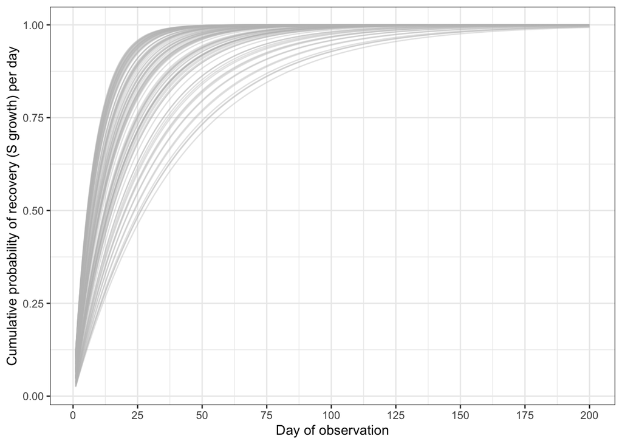

### s_growth (population growth model)

The population growth model is set up such that when S + R exceed total capacity, S growth will take over while R dies off. This is related to decolonisation (mu in the other 2 models).

Note in the graph below, each panel refers to the results from a single combination of parameters.

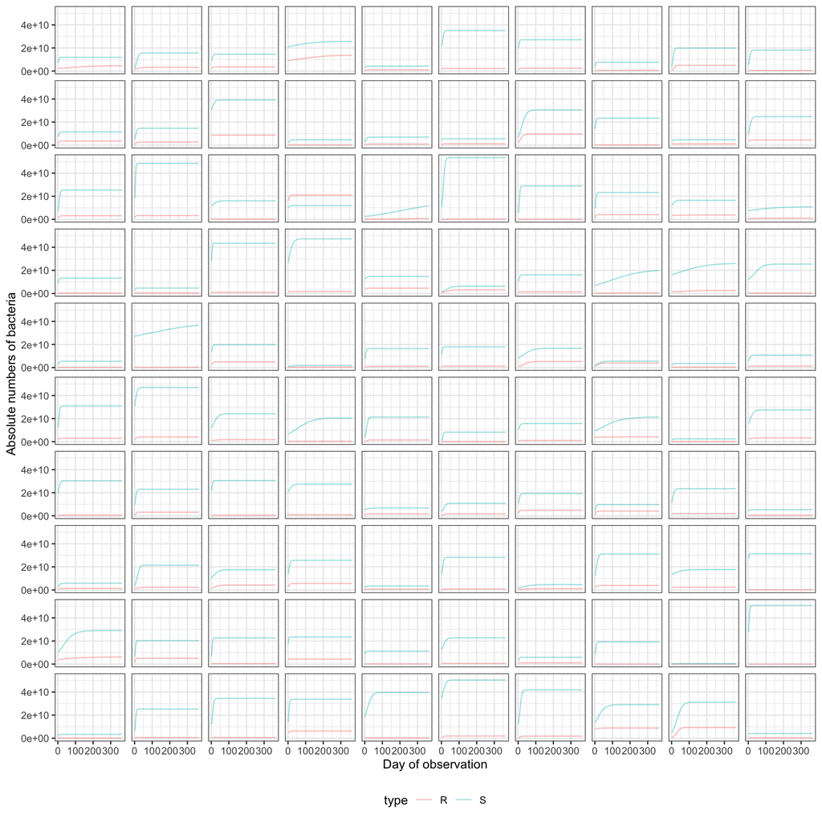

### fitness.r

```r
pop.r = repop.s * fitness.r
```

Taken arbitrarily at 0.1 (very slow R growth compared to S growth) to 5 (faster growth than S)

## $\color{blue}{\text{Antibiotic killing}}$

Karslake Plos Comp. Biol 2016 : The inhibitory effects of antibiotics often decrease with increasing density of the starting microbial population, a phenomenon known as the inoculum effect

Hence we take antibiotic killing to be density dependent in the population growth model.

### abx.s (Third generation cephalosporin for third generation cephalosporin resistance)

- Kemmerich 1983: E coli 9 log to <3 log after ceftazidime for 8 days

Note in the graph below, each panel refers to the results from a single combination of parameters.

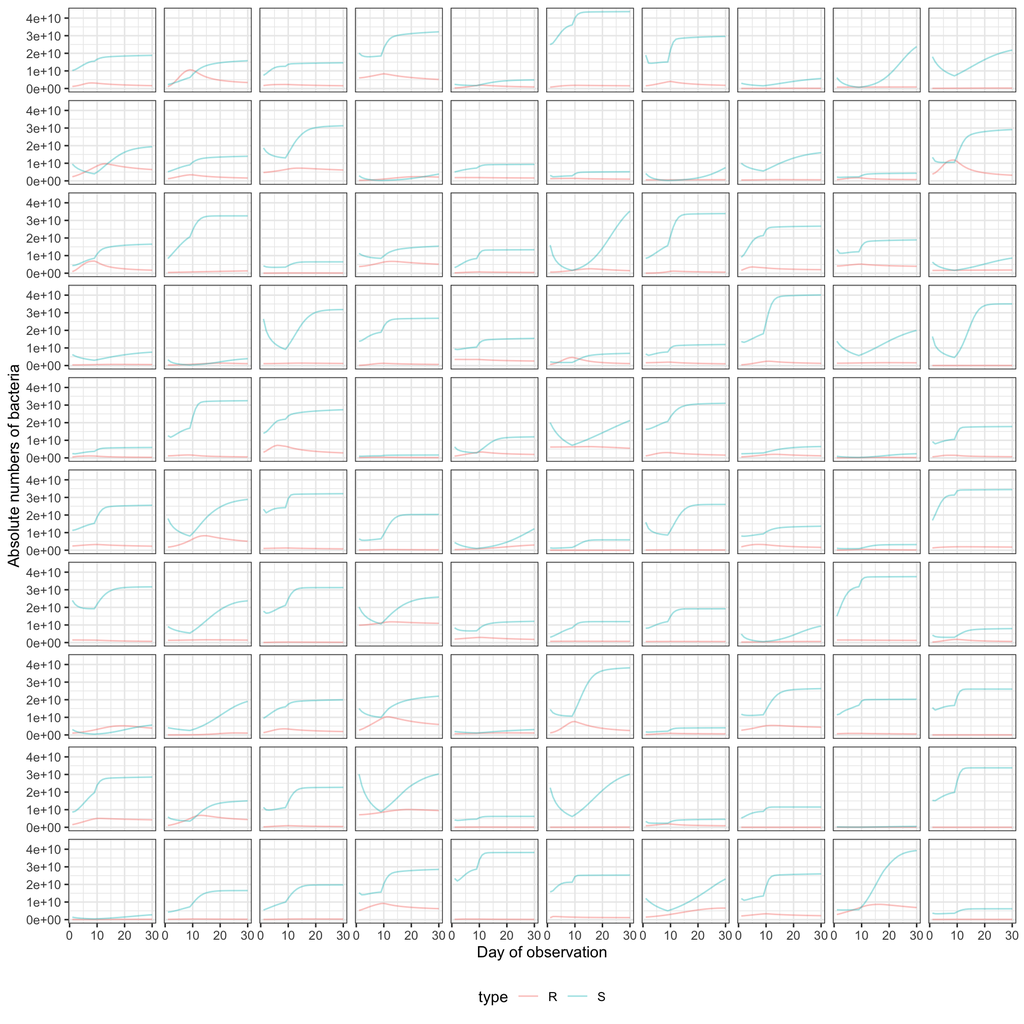

### abx.r (Carbapenem for third generation cephalosporin resistance)

- Kager 1989: Enterobacteriaceae 4-9 log to <1 log in all patients after 2 days of imipenem

Note in the graph below, each panel refers to the results from a single combination of parameters.

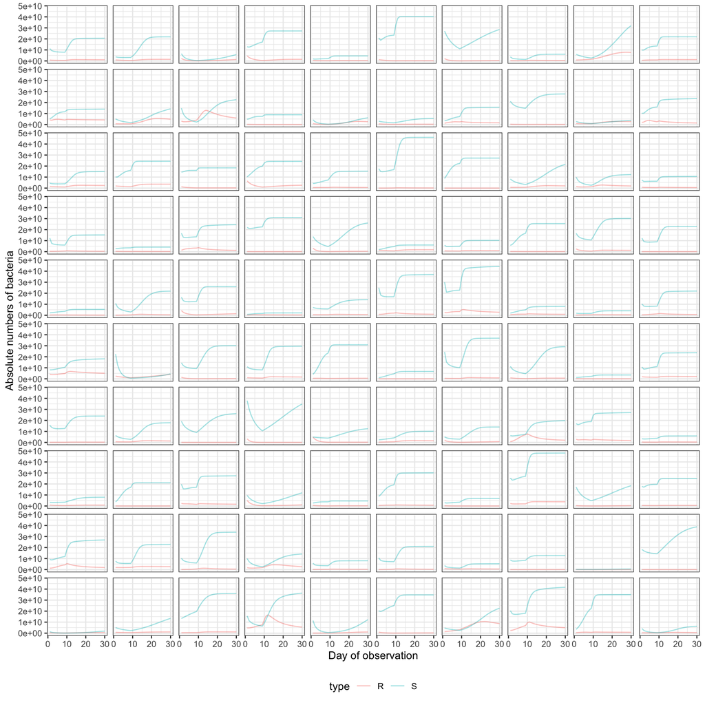